# The Fuel Consumption of Automatic and Manual Vehicles (1973-74 models)

### Overview

The two questions addressed in this project are:

1. Is an automatic or manual transmission better for MPG?
2. What is the MPG difference between automatic and manual transmissions?

I will attempt to answer these questions using a multi-linear regression model with a dependent variable of miles per gallon. The model will include independent variables (control variables) for the characteristics of the engine, such as the number of cylinders and displacement volume, and the car itself, such as rear axle ratio and weight.

### The Data

The data was extracted from the 1974 Motor Trend US magazine, and comprises fuel consumption and 10 aspects of automobile design and performance for 32 automobiles (1973-74 models). A table with more detailed information about each variable can be found in the appendix.

### Exploratory Analysis

The result of the Shapiro-Wilk normality test suggests it is safe to assume the dependent variable is normal with a mean of 20.09 mpg.

The exploratory plots suggest that manual transmission vehicles may be more fuel efficient than automatic transmission vehicles because the top row is slightly higher than the bottom row, but they also illustrate that other factors are probably effecting fuel efficiency.

For example, there seems to be an indirect relationship between fuel efficiency and weight. This builds confidence in the quality of our data because it is reasonable to assume that heavier cars are less fuel efficient. A multi-variate method such as multi-linear regression will accurately assess how a car’s transmission type (automatic/manual) effects its fuel efficiency while controlling for these other relationships.

### Nested Model Testing

```r
# Change cyl to factor variable with 8 cylinders as the reference level #
mtcars$cyl <- relevel(as.factor(mtcars$cyl),"8")

# Create a model for each variable adding variables based on their correlation with mpg #
reg1 <- lm(mpg~am+wt,data=mtcars)
reg2 <- lm(mpg~am+wt+cyl,data=mtcars)
reg3 <- lm(mpg~am+wt+cyl+disp,data=mtcars)
reg4 <- lm(mpg~am+wt+cyl+disp+hp,data=mtcars)
reg5 <- lm(mpg~am+wt+cyl+disp+hp+drat,data=mtcars)
reg6 <- lm(mpg~am+wt+cyl+disp+hp+drat+vs,data=mtcars)
reg7 <- lm(mpg~am+wt+cyl+disp+hp+drat+vs+carb,data=mtcars)
reg8 <- lm(mpg~am+wt+cyl+disp+hp+drat+vs+carb+gear,data=mtcars)
reg9 <- lm(mpg~am+wt+cyl+disp+hp+drat+vs+carb+gear+qsec,data=mtcars)
anova(reg1, reg2, reg3, reg4, reg5, reg6, reg7, reg8, reg9)

# Use the anova table and add variables with a p-value < .1 #
reg10 <- lm(mpg~am+wt+cyl+hp,data=mtcars)
anova(reg2,reg10)
```

[output not shown]

##### Multi-collinearity

```
##    am    wt   cyl    hp
## FALSE  TRUE  TRUE  TRUE
```

Although the Anova tests above would recommend $mpg = \beta_0 + \beta_1am + \beta_2wt + \beta_3cyl + \beta_4hp + \epsilon$, this model has a multi-collinearity problem (3/4 of the variables are collinear).

### Final Stepwise Regression Model

In order to determine which variables to include in the final model and to avoid the multi-collinearity issue, I used an R stepwise regression function, step(), and set the direction=both. This function adds and removes independent variables to the model until it finds the combination of independent variables that minimizes the AIC of the model.

$mpg = \beta_0 + \beta_1 am + \beta_2 qsec + \beta_3 wt + \epsilon$

```
##             Estimate Std. Error t value Pr(>|t|)
## (Intercept)    9.618      6.960   1.382    0.178
## am             2.936      1.411   2.081    0.047
## qsec           1.226      0.289   4.247    0.000
## wt            -3.917      0.711  -5.507    0.000
```

Adjusted R<sup>2</sup> = 0.834

# Conclusion

Many characteristics of cars are highly correlated with each other. For example, heavy cars tend to have larger engines and powerful engines tend to have more cylinders (see correlation matrix in the appendix). This results in multi-colinearity issues.

## Appendix

#### Variable Descriptions

| Variable Name | Description |
| --- | --- |
| *mpg* | Miles/(US) gallon |
| **am** | Transmission (0 = automatic, 1 = manual) |
| cyl | Number of cylinders |
| disp | Displacement (cu.in.) |
| hp | Gross horsepower |
| drat | Rear axle ratio |
| wt | Weight (lb/1000) |
| qsec | 1/4 mile time |
| vs | V/S |
| gear | Number of forward gears |
| carb | Number of carburetors |

#### Dependent Variable *mpg*

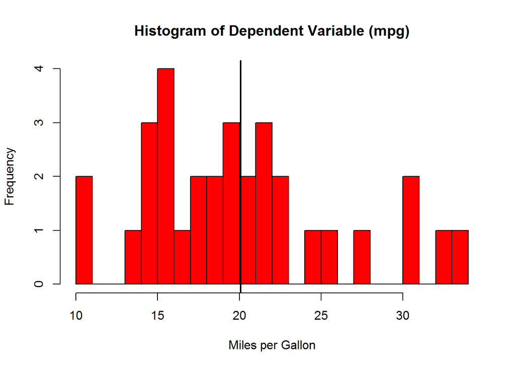

```
##
##  Shapiro-Wilk normality test
##
## data:  mtcars$mpg
## W = 0.94756, p-value = 0.1229
```

#### Exploratory Plots

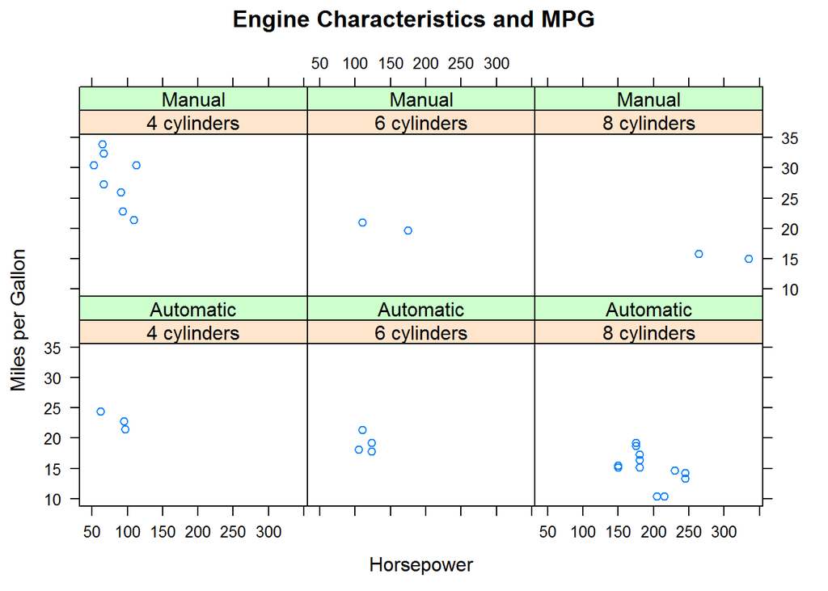

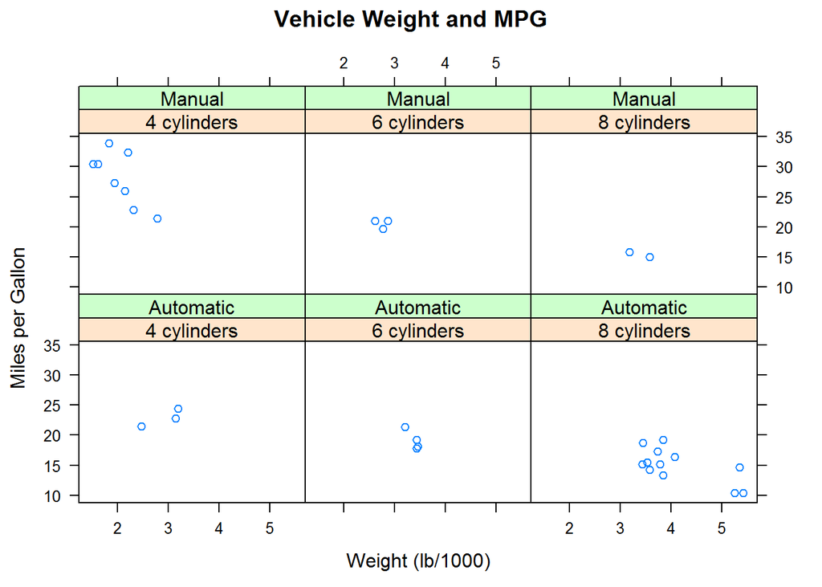

#### Regression Diagnostics

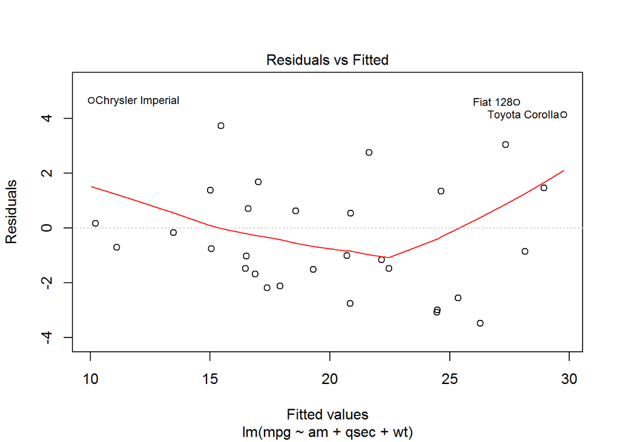

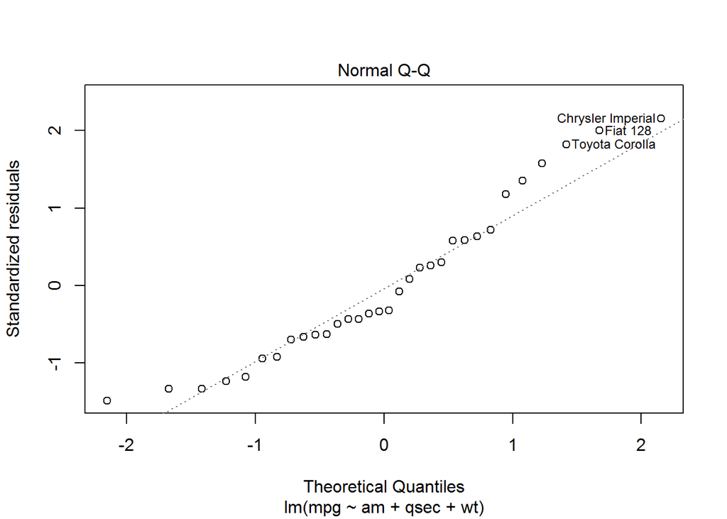

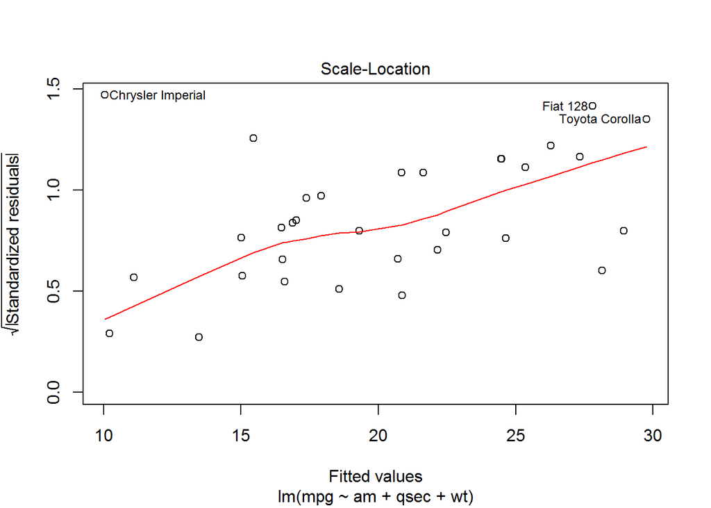

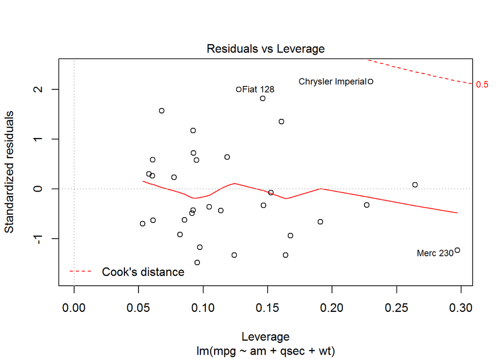

#### Summary Statistics

```
##       mpg                 cyl          disp             hp
##  Min.   :10.40   4 cylinders:11   Min.   : 71.1   Min.   : 52.0
##  1st Qu.:15.43   6 cylinders: 7   1st Qu.:120.8   1st Qu.: 96.5
##  Median :19.20   8 cylinders:14   Median :196.3   Median :123.0
##  Mean   :20.09                    Mean   :230.7   Mean   :146.7
##  3rd Qu.:22.80                    3rd Qu.:326.0   3rd Qu.:180.0
##  Max.   :33.90                    Max.   :472.0   Max.   :335.0
##       drat             wt             qsec             vs
##  Min.   :2.760   Min.   :1.513   Min.   :14.50   Min.   :0.0000
##  1st Qu.:3.080   1st Qu.:2.581   1st Qu.:16.89   1st Qu.:0.0000
##  Median :3.695   Median :3.325   Median :17.71   Median :0.0000
##  Mean   :3.597   Mean   :3.217   Mean   :17.85   Mean   :0.4375
##  3rd Qu.:3.920   3rd Qu.:3.610   3rd Qu.:18.90   3rd Qu.:1.0000
##  Max.   :4.930   Max.   :5.424   Max.   :22.90   Max.   :1.0000
##          am          gear            carb
##  Automatic:19   Min.   :3.000   Min.   :1.000
##  Manual   :13   1st Qu.:3.000   1st Qu.:2.000
##                 Median :4.000   Median :2.000
##                 Mean   :3.688   Mean   :2.812
##                 3rd Qu.:4.000   3rd Qu.:4.000
##                 Max.   :5.000   Max.   :8.000
```

#### Correlation Matrix

```
##             mpg        cyl       disp         hp        drat         wt
## mpg   1.0000000 -0.8521620 -0.8475514 -0.7761684  0.68117191 -0.8676594
## cyl  -0.8521620  1.0000000  0.9020329  0.8324475 -0.69993811  0.7824958
## disp -0.8475514  0.9020329  1.0000000  0.7909486 -0.71021393  0.8879799
## hp   -0.7761684  0.8324475  0.7909486  1.0000000 -0.44875912  0.6587479
## drat  0.6811719 -0.6999381 -0.7102139 -0.4487591  1.00000000 -0.7124406
## wt   -0.8676594  0.7824958  0.8879799  0.6587479 -0.71244065  1.0000000
## qsec  0.4186840 -0.5912421 -0.4336979 -0.7082234  0.09120476 -0.1747159
## vs    0.6640389 -0.8108118 -0.7104159 -0.7230967  0.44027846 -0.5549157
## am    0.5998324 -0.5226070 -0.5912270 -0.2432043  0.71271113 -0.6924953
## gear  0.4802848 -0.4926866 -0.5555692 -0.1257043  0.69961013 -0.5832870
## carb -0.5509251  0.5269883  0.3949769  0.7498125 -0.09078980  0.4276059
##             qsec         vs          am       gear        carb
## mpg   0.41868403  0.6640389  0.59983243  0.4802848 -0.55092507
## cyl  -0.59124207 -0.8108118 -0.52260705 -0.4926866  0.52698829
## disp -0.43369788 -0.7104159 -0.59122704 -0.5555692  0.39497686
## hp   -0.70822339 -0.7230967 -0.24320426 -0.1257043  0.74981247
## drat  0.09120476  0.4402785  0.71271113  0.6996101 -0.09078980
## wt   -0.17471588 -0.5549157 -0.69249526 -0.5832870  0.42760594
## qsec  1.00000000  0.7445354 -0.22986086 -0.2126822 -0.65624923
## vs    0.74453544  1.0000000  0.16834512  0.2060233 -0.56960714
## am   -0.22986086  0.1683451  1.00000000  0.7940588  0.05753435
## gear -0.21268223  0.2060233  0.79405876  1.0000000  0.27407284
## carb -0.65624923 -0.5696071  0.05753435  0.2740728  1.00000000
```